# Simulating data from summary statistics with stats2data

# Overview

`stats2data` simulates raw datasets whose summary statistics match reported summary statistics (the *targets*). Each module defines an objective, the discrepancy between the summary statistics of a candidate dataset and the targets, and minimizes it with simulated annealing. A run stops once the best objective value falls below the convergence threshold `thresh` or once the iteration budget is spent. In this vignette, a run whose best objective value is below `thresh` is called *converged*.

Convergence is a statement about the optimization only, that is, the simulated summary statistics reproduce the targets to within `thresh`. Many different datasets share the same summary statistics, and a simulated dataset is one of them. The results below are therefore described in terms of the optimization objective values, target-vs-simulated differences, run-to-run variability.

The vignette works through four examples:

1. the **Descriptives module** (`optim_vec()`), using summary statistics of a simulated dataset with continuous and integer variables;
2. the **ANOVA module** (`optim_aov()`), using the reported cell means and F-statistics of Reynolds and Besner (2008);
3. the **MLR module** (`optim_mlr()`), using the reported descriptives, correlations, and regression estimates of Bardwell et al. (2003, 2007);
4. the **parallel workflow** (`parallel_optim()`), using the MLR example.

Across the examples, the following functions are demonstrated:

- the optimization functions `optim_vec()`, `optim_aov()`, `optim_mlr()`, and `parallel_optim()`, and the refinement step `hill_climb()`;
- the GRIM check `check_grim()`;
- the inspection methods `print()`, `summary()`, `get_stats()`, `get_rmse()`, and `coef()`;
- the plotting functions `plot_convergence()`, `plot_cooling()`, `plot_fit()`, `plot_stability()`, and the `plot()` methods;
- the Shiny interface `run_app()`.

## Installation

```r
# release version from CRAN
install.packages("stats2data")

# development version from GitHub
# install.packages("remotes")
remotes::install_github("sebastian-lortz/stats2data")
```

## Setup

```r
library(stats2data)
library(ggplot2)
```

# 1. Descriptives module: simulated example

`optim_vec()` simulates one vector per variable that reproduces a target mean and SD within given bounds. To illustrate its use, the targets are computed from a small simulated dataset with two continuous variables and one integer-valued variable.

## 1.1 Encoding the targets

```r
set.seed(2026)
N <- 150
example_data <- data.frame(
  x1 = rnorm(N, mean = 100, sd = 15),           # continuous, symmetric
  x2 = rgamma(N, shape = 2, scale = 3),         # continuous, right-skewed
  x3 = rbinom(N, size = 20, prob = 0.3)         # integer-valued
)
```

The targets are the means and SDs rounded to two decimals, as they would typically be reported. The bounds are the observed minimum and maximum, rounded outward:

```r
target_mean <- round(sapply(example_data, mean), 2)
target_sd   <- round(sapply(example_data, sd), 2)
range       <- rbind(lower = floor(sapply(example_data, min)),
                     upper = ceiling(sapply(example_data, max)))
integer     <- c(FALSE, FALSE, TRUE)

target_mean
```

```
#>    x1    x2    x3
#> 99.65  6.25  6.15
```

```r
target_sd
```

```
#>    x1    x2    x3
#> 15.36  4.15  2.26
```

```r
range
```

```
#>        x1 x2 x3
#> lower  61  0  1
#> upper 140 23 13
```

`range` holds one column of lower and upper bounds per variable; a vector of length two applies the same bounds to all variables. `integer` marks which variables are integer-valued.

## 1.2 GRIM check

For integer-valued data, not every mean is attainable: the sum of `N` integers divided by `N` can only take values on a grid of width `1 / N`. The GRIM test (Brown & Heathers, 2017) checks whether a reported mean, rounded to `decimals`, lies on that grid:

```r
check_grim(n = N, target_mean = target_mean[["x3"]], decimals = 2)
```

```
#> $test
#> [1] TRUE
#>
#> $grim_mean
#> [1] 6.15
```

For a mean that fails, `grim_mean` returns the nearest attainable mean (hypothetical values):

```r
check_grim(n = 7, target_mean = 3.45, decimals = 2)
```

```
#> $test
#> [1] FALSE
#>
#> $grim_mean
#> [1] 3.43
```

## 1.3 Running the optimizer

For continuous variables, `optim_vec()` starts from a vector whose mean lies within `thresh` of the target mean and anneals the values toward the target SD; the moves keep the mean fixed. For integer variables, it draws a distribution from SPRITE (Heathers et al., 2018) via `rsprite2` whose mean and SD match the targets at the number of decimals given by `sprite_prec`. The objective of each variable is the absolute difference between its simulated and target SD.

Both statistics are given to two decimals, so `sprite_prec = c(2, 2)`, and `thresh = 0.005` is set to half a unit of the last decimal (both are the defaults). The remaining arguments are at their defaults (`max_iter = 5e5`, `init_temp = 1e-3`, `cooling_rate = NULL`, i.e. `(max_iter - 10) / max_iter`, `max_starts = 3`).

```r
set.seed(2026)
result_vec <- optim_vec(
  N           = N,
  target_mean = target_mean,
  target_sd   = target_sd,
  range       = range,
  integer     = integer,
  sprite_prec = c(2, 2),
  thresh      = 0.005
)
```

## 1.4 Inspecting the result

`print()` shows the sample size and the best objective value per variable:

```r
result_vec
```

```
#> stats2data Descriptives result
#>   Variables: 3
#>   N:         150
#>   Best objective per variable:
#>     x1: 0.002753
#>     x2: 0.004366
#>     x3: 0.0003847
```

The best objective values are below `thresh = 0.005` for all three variables. `summary()` adds the target and simulated means and SDs and their RMSEs; the largest absolute difference between a simulated and a target mean is 0.00499:

```r
summary(result_vec)
```

```
#> stats2data Descriptives Summary
#> -----------------------------------------------
#> N: 150  | Variables: 3
#>
#> Best objective per variable:
#>   x1: 0.002753
#>   x2: 0.004366
#>   x3: 0.0003847
#>
#> RMSE
#>   Means: 0.004505
#>   SDs:   0.002988
#>
#> Target vs. Simulated:
#>  variable target_mean sim_mean target_sd sim_sd
#>        x1       99.65   99.645     15.36 15.357
#>        x2        6.25    6.255      4.15  4.146
#>        x3        6.15    6.147      2.26  2.260
```

`get_stats()` returns the simulated statistics and `get_rmse()` the RMSEs between simulated and target statistics:

```r
get_stats(result_vec)
```

```
#> $mean
#>        x1        x2        x3
#> 99.645019  6.254995  6.146667
#>
#> $sd
#>        x1        x2        x3
#> 15.357247  4.145634  2.259615
```

```r
get_rmse(result_vec)
```

```
#> $rmse_mean
#> [1] 0.004504504
#>
#> $rmse_sd
#> [1] 0.002988441
```

If SPRITE finds no distribution for an integer variable, the reason is stored per variable in `error_msgs` (`NULL` when SPRITE succeeded):

```r
result_vec$error_msgs
```

## 1.5 Diagnostics

`plot_convergence()` shows the best objective value across iterations. For a `stats2data_vec` result, `run` selects the variable. `log_y = TRUE` uses a logarithmic y axis, and the shaded band marks the region below `thresh`.

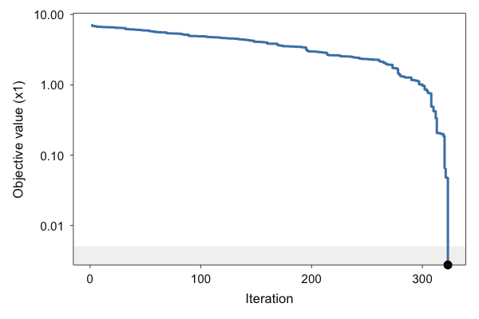

```r
plot_convergence(result_vec, run = 1, log_y = TRUE)
```

The trajectory of `x1` has 323 iterations. Integer variables are drawn by SPRITE without annealing, so their trajectory consists of a single value.

`plot_cooling()` shows the temperature schedule implied by `init_temp`, `cooling_rate`, and `max_iter`:

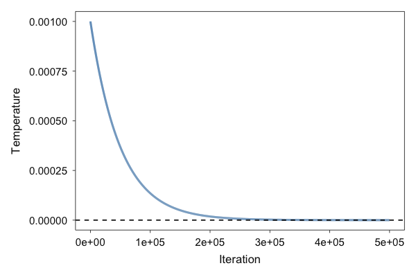

```r
plot_cooling(result_vec)
```

## 1.6 Target vs. simulated statistics

`plot_fit()` plots the difference between simulated and target statistics. With `standardised = FALSE`, the differences are on the original scale; the shaded band marks `+/- thresh`. `order = "fit"` sorts the statistics by absolute difference.

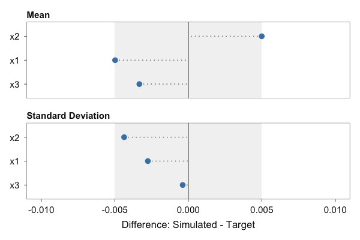

```r
plot_fit(result_vec, standardised = FALSE, order = "fit")
```

The same plots are available through `plot()`, with `which` selecting the panel:

```r
plot(result_vec)                    # plot_convergence()
plot(result_vec, which = "cooling") # plot_cooling()
plot(result_vec, which = "fit")     # plot_fit()
```

## 1.7 Simulated data

The simulated data are stored in `result_vec$data`, one column per variable:

```r
data_vec <- result_vec$data
head(data_vec)
```

```
#>          x1       x2 x3
#> 1 108.56228 6.043737  9
#> 2 109.49172 1.140020  9
#> 3  93.02921 8.372150  6
#> 4  94.24471 1.906615  6
#> 5  98.47697 1.315124  6
#> 6  76.09617 7.676196  9
```

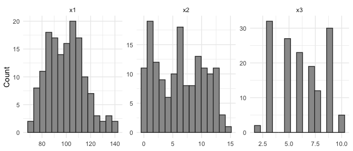

```r
data_long <- data.frame(
  variable = factor(rep(names(data_vec), each = nrow(data_vec)), levels = names(data_vec)),
  value    = unlist(data_vec, use.names = FALSE)
)
ggplot(data_long, aes(x = value)) +
  geom_histogram(bins = 15, fill = "grey60", colour = "grey20") +
  facet_wrap(~ variable, scales = "free") +
  labs(x = NULL, y = "Count") +
  theme_minimal()
```

# 2. ANOVA module: Reynolds and Besner (2008)

Reynolds and Besner (2008, Experiment 5) examined how contextual predictability affects response times in word and nonword naming; the study was among those replicated by the Open Science Collaboration (2015). To our knowledge, the raw data are not publicly available.

## 2.1 Reported summary statistics

The study reports a 2 x 2 within-subjects design (`S = 16`) with four cell means, indexed by stimulus type (`Factor1`) and switch condition (`Factor2`): 543, 536, 614, and 618 ms. It reports `MSE = 3070` for the `Factor1` effect, `F(1, 15) = 30.5` (partial eta squared .670) for `Factor1`, and `F < 1` for `Factor2` (.002) and the interaction (.015).

```r
S   <- 16
mse <- 3070
target_group_means <- c(543, 536, 614, 618)
eta2   <- c(0.002, 0.015)  # Factor2, Factor1:Factor2
df_err <- S - 1
```

The numerator mean squares implied by the cell means of the balanced 2 x 2 within-subjects design are:

```r
m_cell  <- matrix(target_group_means, nrow = 2, byrow = TRUE)  # rows: Factor1, cols: Factor2
m_grand <- mean(m_cell)
ms_f1   <- S * 2 * sum((rowMeans(m_cell) - m_grand)^2)
ms_f2   <- S * 2 * sum((colMeans(m_cell) - m_grand)^2)
ms_int  <- S * sum((m_cell - outer(rowMeans(m_cell), colMeans(m_cell), "+") + m_grand)^2)
c(ms_f1 = ms_f1, ms_f2 = ms_f2, ms_int = ms_int)
```

```
#>  ms_f1  ms_f2 ms_int
#>  93636     36    484
```

The reported `Factor1` statistics are consistent with each other: the implied mean square divided by the reported `MSE` gives `F = 30.5`, and `F / (F + df_error)` gives the reported partial eta squared of .670.

```r
stopifnot(round(ms_f1 / mse, 1) == 30.5)
stopifnot(round(30.5 / (30.5 + df_err), 3) == 0.670)
```

For the two effects reported as `F < 1`, the F-statistics are set from the reported partial eta squared via `F = eta^2 * df_error / (1 - eta^2)` (one numerator degree of freedom). The modules require bounds for the outcome, which the study does not report; the range of the reported cell means is extended by four times `sqrt(MSE)`, the residual SD implied by the MSE, and rounded outward. The summary statistics are encoded in one list of `optim_aov()` arguments:

```r
F_value_derived <- c(round(ms_f1 / mse, 1), round(eta2 * df_err / (1 - eta2), 3))

sumstats <- list(
  S                  = S,
  levels             = c(2, 2),
  factor_type        = c("within", "within"),
  formula            = "outcome ~ Factor1 * Factor2 + Error(ID / (Factor1 * Factor2))",
  integer            = FALSE,
  target_f_list      = list(
    effect  = c("Factor1", "Factor2", "Factor1:Factor2"),
    F_value = F_value_derived
  ),
  target_group_means = target_group_means,
  range              = c(floor(min(target_group_means) - 4 * sqrt(mse)),
                         ceiling(max(target_group_means) + 4 * sqrt(mse)))
)
sumstats$target_f_list$F_value
```

```
#> [1] 30.500  0.030  0.228
```

```r
sumstats$range
```

```
#> [1] 314 840
```

`target_group_means` lists the cells with `Factor1` varying slowest (11, 12, 21, 22). Between-subjects and mixed designs are specified through `factor_type` (and, for unequal group sizes, `subgroup_sizes`).

## 2.2 Simulating a dataset

`optim_aov()` is called with its default hyperparameters (`max_iter = 3e4`, `thresh = 0.005`, `max_starts = 3`, `init_temp = 1e-3`, `cooling_rate = NULL`, i.e. `(max_iter - 10) / max_iter`). The objective is the RMSE between the simulated and target F-statistics.

```r
set.seed(2026)
result_aov <- do.call(optim_aov, sumstats)
```

## 2.3 Inspecting the output

```r
result_aov
```

```
#> stats2data ANOVA result
#>   Design:    2 x 2 (within, within)
#>   Subjects:   16
#>   Effects:    Factor1, Factor2, Factor1:Factor2
#>   Best objective: 0.00346117
```

```r
summary(result_aov)
```

```
#> stats2data ANOVA Summary
#> -----------------------------------------------
#> Design:     2 x 2 (within, within)
#> Subjects:
#> Best objective: 0.00346117
#>
#> RMSE
#>   F-statistics: 0.003461
#>   Group means:  9.747e-13
#>
#> -----------------------------------------------
#> F-values (Target vs. Simulated):
#>           effect target_F    sim_F
#>          Factor1   30.500 30.49911
#>          Factor2    0.030  0.02408
#>  Factor1:Factor2    0.228  0.22774
#>
#> -----------------------------------------------
#> Group Means (Target vs. Simulated):
#>        cell target_mean sim_mean
#>  F1=1, F2=1         543      543
#>  F1=1, F2=2         536      536
#>  F1=2, F2=1         614      614
#>  F1=2, F2=2         618      618
```

The simulated F-statistics are 30.499, 0.024, 0.228 for `Factor1`, `Factor2`, and `Factor1:Factor2` (targets 30.5, 0.030, 0.228); the F-statistic RMSE is 0.003 and the cell-mean RMSE 0.000000000000975.

Before the annealing, `optim_aov()` may shift the target cell means by less than `thresh` so that the means and F-statistics can be matched jointly. The values used are stored in `adjusted_targets`:

```r
result_aov$adjusted_targets
```

```
#> $group_means
#> [1] 543 536 614 618
#>
#> $F_values
#> [1] 30.500  0.030  0.228
```

`get_stats()` returns the ANOVA table of the simulated data (fitted with `afex`), the F-statistics, and the cell means; `get_rmse()` returns the two RMSEs:

```r
get_stats(result_aov)
```

```
#> $model
#> Anova Table (Type 3 tests)
#>
#> Response: outcome
#>                 num Df den Df    MSE       F     ges    Pr(>F)
#> Factor1              1     15 3070.1 30.4991 0.43050 5.852e-05 ***
#> Factor2              1     15 1495.2  0.0241 0.00029    0.8788
#> Factor1:Factor2      1     15 2125.2  0.2277 0.00389    0.6401
#> ---
#> Signif. codes:  0 '***' 0.001 '**' 0.01 '*' 0.05 '.' 0.1 ' ' 1
#>
#> $F_value
#> [1] 30.49911423  0.02407665  0.22773815
#>
#> $mean
#> 1_1 1_2 2_1 2_2
#> 543 536 614 618
```

```r
get_rmse(result_aov)
```

```
#> $rmse_F
#> [1] 0.003461175
#>
#> $rmse_mean
#> [1] 9.746616e-13
```

## 2.4 Diagnostics

The convergence trajectory (`first_iter = 1` skips the first iteration) and the target-vs-simulated differences are obtained with:

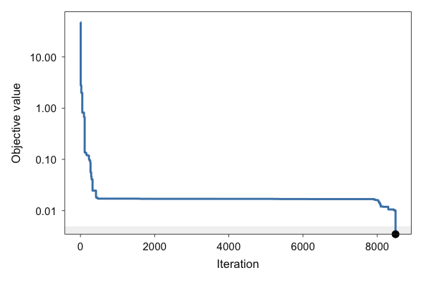

```r
plot_convergence(result_aov, first_iter = 1, log_y = TRUE)
```

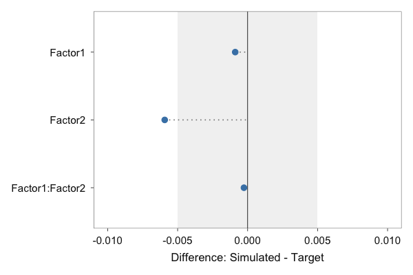

```r
plot_fit(result_aov, standardised = FALSE)
```

`first_iter = 5000` plots from iteration 5000 onwards:

```r
plot_convergence(result_aov, first_iter = 5000)
```

`plot_cooling()` shows the temperature schedule:

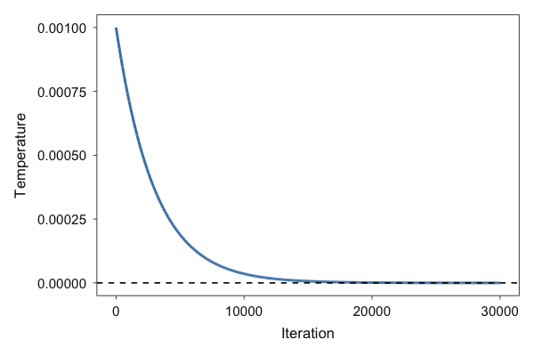

```r
plot_cooling(result_aov)
```

## 2.5 Simulated data

The data are stored in long format, one row per subject and cell. The simulated observations lie within `range`; the second line checks whether any observation equals one of the bounds:

```r
range(result_aov$data$outcome)
```

```
#> [1] 469.2889 735.7955
```

```r
any(result_aov$data$outcome %in% sumstats$range)
```

```
#> [1] FALSE
```

```r
data_aov <- result_aov$data
head(data_aov)
```

```
#>   ID Factor1 Factor2  outcome
#> 1  1       1       1 526.5609
#> 2  1       1       2 594.2713
#> 3  1       2       1 641.5214
#> 4  1       2       2 551.0167
#> 5  2       1       1 535.8782
#> 6  2       1       2 549.8449
```

```r
aggregate(outcome ~ Factor1 + Factor2, data = data_aov, FUN = mean)
```

```
#>   Factor1 Factor2 outcome
#> 1       1       1     543
#> 2       2       1     614
#> 3       1       2     536
#> 4       2       2     618
```

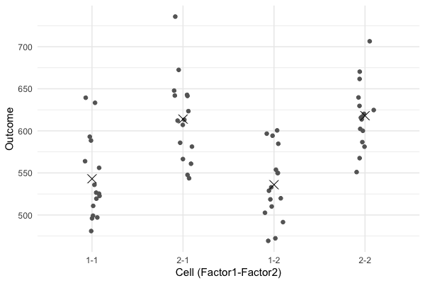

```r
ggplot(data_aov, aes(x = interaction(Factor1, Factor2, sep = "-"), y = outcome)) +
  geom_jitter(width = 0.1, colour = "grey40") +
  stat_summary(fun = mean, geom = "point", shape = 4, size = 4) +
  labs(x = "Cell (Factor1-Factor2)", y = "Outcome") +
  theme_minimal()
```

Crosses mark the simulated cell means.

# 3. MLR module: Bardwell et al. (2003)

Bardwell et al. (2003) examined whether depressive symptoms or apnea severity better predict fatigue in `N = 60` patients with obstructive sleep apnea. This example uses the statistics reported there:

- means, SDs, and ranges from Table 1;
- the regression of fatigue on both apnea indices and depressive symptoms (Step 2) from Table 2;
- the correlations of the three predictors with fatigue from the Results section.

The same descriptives and coefficients are reprinted in Bardwell et al. (2007), with ranges rounded to integers. The variables are the respiratory disturbance index (`RDI`), the percentage of time with oxygen saturation below 90% (`SaO2`), the Center for Epidemiological Studies Depression Scale score (`CESD`), and the fatigue-inertia subscale of the Profile of Mood States (`Fatigue`). To our knowledge, the raw data are not publicly available.

## 3.1 Encoding the targets

```r
N           <- 60
target_mean <- c(RDI = 48.8, SaO2 = 17.3, CESD = 12.6, Fatigue = 10.8)
target_sd   <- c(RDI = 27.1, SaO2 = 20.1, CESD = 11.3, Fatigue = 7.3)
range       <- rbind(lower = c(RDI =  15, SaO2 =  0, CESD =  0, Fatigue =  0),
                     upper = c(RDI = 111, SaO2 = 80.9, CESD = 49, Fatigue = 28))
integer     <- c(FALSE, FALSE, TRUE, TRUE)
```

`RDI` and `SaO2` are treated as continuous, `CESD` and `Fatigue` as integer-valued sum scores. Both means pass the GRIM check:

```r
vapply(c("CESD", "Fatigue"), function(v) {
  check_grim(n = N, target_mean = target_mean[[v]], decimals = 1)$test
}, logical(1))
```

```
#>    CESD Fatigue
#>    TRUE    TRUE
```

`target_cor` holds the upper triangle of the correlation matrix of all variables in `target_mean`, in the order of `target_mean`. Unreported correlations are `NA` and excluded from the objective:

```r
vars    <- names(target_mean)
cor_mat <- matrix(NA_real_, 4, 4, dimnames = list(vars, vars))
cor_mat["RDI",  "Fatigue"] <- 0.11
cor_mat["SaO2", "Fatigue"] <- 0.20
cor_mat["CESD", "Fatigue"] <- 0.68
target_cor <- cor_mat[upper.tri(cor_mat)]
target_cor
```

```
#> [1]   NA   NA   NA 0.11 0.20 0.68
```

`target_reg` and `target_se` follow the terms of `reg_equation`, intercept first. The intercept is not reported; it is derived from the means and slopes via `b0 = mean(Fatigue) - sum(b * mean(X))`, and its standard error is set to `NA`:

```r
reg_equation <- "Fatigue ~ RDI + SaO2 + CESD"
b            <- c(RDI = 0.023, SaO2 = 0.008, CESD = 0.438)
b0           <- target_mean[["Fatigue"]] - sum(b * target_mean[names(b)])
target_reg   <- c("(Intercept)" = round(b0, 3), b)
target_se    <- c(NA, 0.034, 0.048, 0.066)
target_reg
```

```
#> (Intercept)         RDI        SaO2        CESD
#>       4.020       0.023       0.008       0.438
```

The arguments are collected in one list, which is reused in Section 4:

```r
args_mlr <- list(
  N            = N,
  target_mean  = target_mean,
  target_sd    = target_sd,
  range        = range,
  integer      = integer,
  sprite_prec  = c(1, 1),
  reg_equation = reg_equation,
  target_cor   = target_cor,
  target_reg   = target_reg,
  target_se    = target_se,
  thresh       = 0.005
)
```

## 3.2 Running the optimizer

`optim_mlr()` first calls `optim_vec()` to simulate the marginals and then optimizes the values of the predictors with simulated annealing, followed by hill climbing (`hill_climbs`). In the marginal step, `thresh` applies to the continuous variables; the integer variables are matched by SPRITE to the precision given by `sprite_prec`. The objective is `weight * correlation error + (1 - weight) * regression error`, where the regression error includes the standard errors when `target_se` is given.

The call uses `thresh = 0.005`, the default of `optim_mlr()`, which equals half a unit of the second decimal, the precision of the reported correlations. A stricter threshold would demand more precision than the reported statistics carry. The coefficients are reported to three decimals, but they depend on means and SDs rounded to one decimal. For example, the rounding of the SDs of `Fatigue` (7.3) and `CESD` (11.3) alone leaves the `CESD` slope (0.438) uncertain by about +/- 0.005.

All other arguments are `sprite_prec = c(1, 1)` (one reported decimal) and the defaults (`weight = 0.5`, `max_iter = 1e5`, `max_starts = 3`, `hill_climbs = 1e4`; `init_temp = NULL` is calibrated from the objective changes of random swaps, `cooling_rate = NULL` is `(max_iter - 10) / max_iter`).

```r
set.seed(2026)
result_mlr <- do.call(optim_mlr, args_mlr)
```

## 3.3 Inspecting the result

```r
result_mlr
```

```
#> stats2data MLR result
#>   N:          60
#>   Equation:   Fatigue ~ RDI + SaO2 + CESD
#>   Best objective: 0.00264369
```

```r
summary(result_mlr)
```

```
#> stats2data MLR Summary
#> -----------------------------------------------
#> N: 60  | Model: Fatigue ~ RDI + SaO2 + CESD
#> Best objective: 0.00264369
#>
#> RMSE
#>   Correlations:             0.0001228
#>   Regression Coefficients:  0.001257
#>   Standard Errors:          0.007754
#>
#> Descriptives (Target vs. Simulated):
#>  variable target_mean sim_mean target_sd sim_sd
#>       RDI        48.8    48.80      27.1  27.10
#>      SaO2        17.3    17.30      20.1  20.10
#>      CESD        12.6    12.62      11.3  11.34
#>   Fatigue        10.8    10.75       7.3   7.35
#>
#> Coefficients (Target vs. Simulated):
#>         term target_reg  sim_reg target_se  sim_se
#>  (Intercept)      4.020 4.020111        NA 1.68535
#>          RDI      0.023 0.022763     0.034 0.02645
#>         SaO2      0.008 0.007072     0.048 0.03691
#>         CESD      0.438 0.435678     0.066 0.06532
#>
#> Correlations (Target vs. Simulated):
#>          pair target_cor sim_cor
#>      RDI-SaO2         NA 0.06857
#>      RDI-CESD         NA 0.03695
#>     SaO2-CESD         NA 0.26025
#>   RDI-Fatigue       0.11 0.11007
#>  SaO2-Fatigue       0.20 0.20000
#>  CESD-Fatigue       0.68 0.68020
```

`get_stats()` returns the fitted `lm` object, the coefficients, standard errors, correlations (upper triangle in the order predictors, outcome), means, and SDs of the simulated data. `coef()` refits the regression and returns the coefficients:

```r
stats_mlr <- get_stats(result_mlr)
names(stats_mlr)
```

```
#> [1] "model" "reg"   "se"    "cor"   "mean"  "sd"
```

```r
summary(stats_mlr$model)
```

```
#>
#> Call:
#> stats::lm(formula = frm, data = d)
#>
#> Residuals:
#>      Min       1Q   Median       3Q      Max
#> -12.1842  -3.1674   0.0075   3.1851  15.5366
#>
#> Coefficients:
#>             Estimate Std. Error t value Pr(>|t|)
#> (Intercept) 4.020111   1.685345   2.385   0.0205 *
#> RDI         0.022763   0.026451   0.861   0.3932
#> SaO2        0.007072   0.036912   0.192   0.8488
#> CESD        0.435678   0.065315   6.670 1.21e-08 ***
#> ---
#> Signif. codes:  0 '***' 0.001 '**' 0.01 '*' 0.05 '.' 0.1 ' ' 1
#>
#> Residual standard error: 5.491 on 56 degrees of freedom
#> Multiple R-squared:  0.4702, Adjusted R-squared:  0.4419
#> F-statistic: 16.57 on 3 and 56 DF,  p-value: 7.949e-08
```

```r
coef(result_mlr)
```

```
#> (Intercept)         RDI        SaO2        CESD
#> 4.020110974 0.022762616 0.007071768 0.435678377
```

```r
get_rmse(result_mlr)
```

```
#> $rmse_cor
#> [1] 0.0001227945
#>
#> $rmse_reg
#> [1] 0.001257002
#>
#> $rmse_se
#> [1] 0.007754376
```

The marginal result of the internal `optim_vec()` call is stored in `result_mlr$optim_vec` and supports the methods of Section 1:

```r
get_rmse(result_mlr$optim_vec)
```

```
#> $rmse_mean
#> [1] 0.02658335
#>
#> $rmse_sd
#> [1] 0.0314791
```

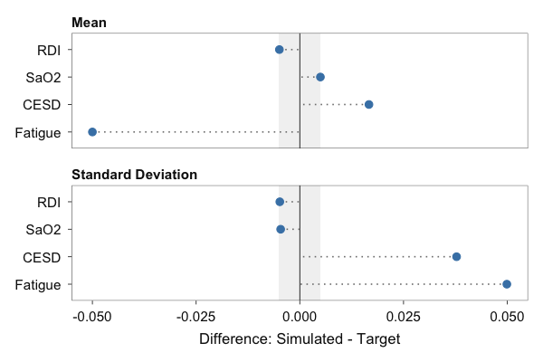

```r
plot_fit(result_mlr$optim_vec, standardised = FALSE)
```

The RMSEs exceed `thresh` because `thresh` applies only to the continuous variables `RDI` and `SaO2`, whereas the integer variables `CESD` and `Fatigue` are matched by SPRITE only to the reported precision (`sprite_prec = c(1, 1)`, i.e. within +/- 0.05).

## 3.4 Diagnostics

`plot_convergence()` shows the best objective value across the annealing iterations; `first_iter` skips leading iterations, here the first 10%:

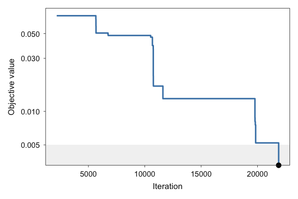

```r
n_iter_mlr <- length(result_mlr$track_objective)
plot_convergence(result_mlr, log_y = TRUE, first_iter = floor(n_iter_mlr / 10))
```

With `ratio = TRUE`, the plot shows the ratio of the correlation error to the regression error of the best candidate, with lines at its mean, median, and final value (`show_mean`, `show_median`, `show_final`). A ratio above 1 means that the correlation component is the larger of the two.

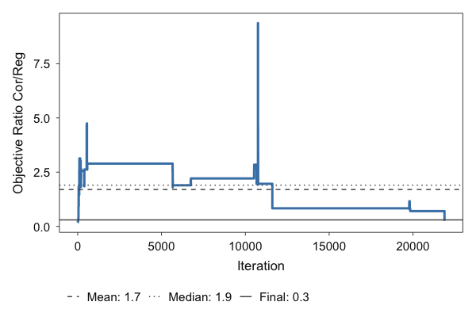

```r
plot_convergence(result_mlr, ratio = TRUE)
```

The final ratio is 0.253.

`plot_cooling()` uses the stored `init_temp` and `cooling_rate`, i.e. the values calibrated during the run:

```r
result_mlr$inputs$init_temp
```

```
#> [1] 0.02971333
```

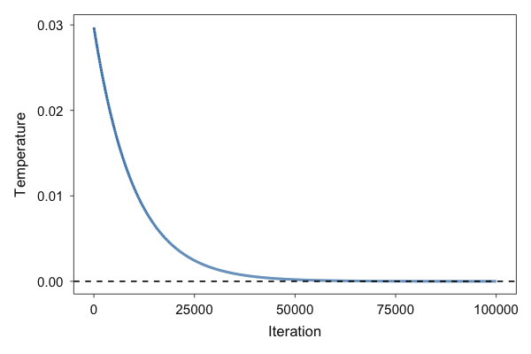

```r
plot_cooling(result_mlr)
```

## 3.5 Balancing the objective with `weight`

`weight` sets how much the correlation and the regression components contribute to the objective. Objective values obtained with different weights are on different scales and are not compared directly; the unweighted RMSEs of `get_rmse()` are. The optimization is repeated with `weight = 0.05`:

```r
set.seed(2026)
result_mlr_w05 <- do.call(optim_mlr, modifyList(args_mlr, list(weight = 0.05)))
```

```r
rbind(
  "weight = 0.5" = unlist(get_rmse(result_mlr)),
  "weight = 0.05" = unlist(get_rmse(result_mlr_w05))
)
```

```
#>                   rmse_cor    rmse_reg     rmse_se
#> weight = 0.5  0.0001227945 0.001257002 0.007754376
#> weight = 0.05 0.0045908802 0.001160531 0.005647967
```

The table shows how the RMSEs of the correlations, coefficients, and standard errors change with `weight` in this example. Which balance is preferable depends on which targets matter most for the intended use of the data. The remainder of this section continues with the `weight = 0.5` result.

## 3.6 Target vs. simulated statistics

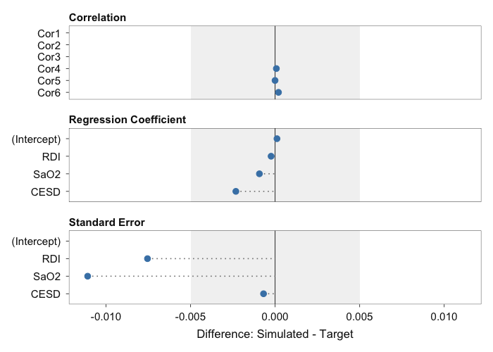

```r
plot_fit(result_mlr, standardised = FALSE)
```

With the default `standardised = TRUE`, the differences are divided by the target values (for targets of zero, the unstandardised difference is shown). The `plot()` method offers the same panels, including `which = "ratio"`:

```r
plot(result_mlr, which = "fit")
plot(result_mlr, which = "ratio")
```

## 3.7 Refinement with `hill_climbs`

After the annealing, `optim_mlr()` refines the best candidate by hill climbing: it repeatedly swaps pairs of values within a predictor column and keeps a swap only if it lowers the objective. `hill_climbs` sets the number of hill-climbing iterations (default `1e4`); `hill_climbs = 0` skips the refinement. The optimization is repeated without refinement and with a longer refinement. With the same seed, the annealing is identical across the calls, so differences reflect the refinement only:

```r
set.seed(2026)
result_mlr_hc0 <- do.call(optim_mlr, modifyList(args_mlr, list(hill_climbs = 0)))

set.seed(2026)
result_mlr_hc5e4 <- do.call(optim_mlr, modifyList(args_mlr, list(hill_climbs = 5e4)))
```

```r
rbind(
  "hill_climbs = 0"   = c(best_objective = result_mlr_hc0$best_objective,
                          unlist(get_rmse(result_mlr_hc0))),
  "hill_climbs = 1e4" = c(best_objective = result_mlr$best_objective,
                          unlist(get_rmse(result_mlr))),
  "hill_climbs = 5e4" = c(best_objective = result_mlr_hc5e4$best_objective,
                          unlist(get_rmse(result_mlr_hc5e4)))
)
```

```
#>                   best_objective     rmse_cor    rmse_reg     rmse_se
#> hill_climbs = 0      0.003278107 0.0013256098 0.001369679 0.007831782
#> hill_climbs = 1e4    0.002643694 0.0001227945 0.001257002 0.007754376
#> hill_climbs = 5e4    0.002643691 0.0001227945 0.001256523 0.007754468
```

`track_objective` covers the annealing only, so the effect of the refinement is visible in `best_objective` and the RMSEs, not in `plot_convergence()`.

## 3.8 Simulated data

```r
data_mlr <- result_mlr$data
head(data_mlr)
```

```
#>         RDI        SaO2 CESD Fatigue
#> 1  41.84422  0.27991433    0       7
#> 2  58.46773 30.75049710   26      15
#> 3  25.72880  4.52863153   25      19
#> 4  68.41232  0.05619894    5      17
#> 5  41.67719  0.43914902    1       1
#> 6 102.26432 69.17220026   29      19
```

# 4. Parallel workflow: Bardwell et al. (2003)

Each run of an optimizer is subject to randomness, and many datasets share the same summary statistics, so repeated runs return different datasets. `parallel_optim()` repeats the optimization with the same arguments and collects the runs; `seed` gives each run its own reproducible random-number stream.

```r
result_par <- parallel_optim(
  FUN   = optim_mlr, # MLR module
  args  = args_mlr,  # reported summary statistics
  runs  = 10,        # number of optimization runs
  cores = 1,         # number of parallel workers
  seed  = 2026       # reproducible seed per run
)
```

With `cores > 1`, `parallel_optim()` sets up a `future::multisession` plan (Bengtsson, 2021) and restores any previous plan on exit. Because every run has its own random-number stream derived from `seed`, the results do not depend on `cores`:

```r
result_par <- parallel_optim(FUN = optim_mlr, args = args_mlr,
                             runs = 10, cores = 2, seed = 2026)
```

## 4.1 Inspecting the parallel output

```r
result_par
```

```
#> stats2data parallel result
#>   Module: mlr
#>   Runs:   10
#>   Best objective (across runs): 0.00228711
#>   Mean objective (across runs): 0.00274523
```

10 of 10 runs have a best objective value below `thresh` = 0.005. Across runs, the best objective values range from 0.00229 to 0.00433.

`summary()` lists the best and mean objective values, the RMSE against the targets and between runs, and the target statistics aggregated across runs:

```r
summary(result_par)
```

```
#> stats2data Parallel Summary
#> -----------------------------------------------
#> Module: mlr  | Runs: 10
#> Best objective:  0.00228711
#> Mean error:  0.00274523
#> SD error:    0.000580672
#>
#> Target RMSE (across runs):
#>    metric      mean        sd       min       max
#>  rmse_cor 7.378e-05 4.468e-05 6.659e-06 0.0001273
#>  rmse_reg 2.668e-03 2.355e-03 1.581e-03 0.0093152
#>   rmse_se 7.410e-03 5.210e-04 6.351e-03 0.0080696
#>
#> Between-run RMSE:
#>    metric      mean        sd       min       max
#>  rmse_cor 7.005e-05 4.753e-05 1.395e-05 0.0001376
#>  rmse_reg 1.713e-03 2.259e-03 2.361e-04 0.0080360
#>   rmse_se 5.663e-04 3.038e-04 2.493e-04 0.0012951
#>
#> Aggregated Statistics:
#>   reg:
#>                mean   median        sd      min     max
#> (Intercept) 4.02015 4.020089 0.0002547 4.019917 4.02078
#> RDI         0.02412 0.024690 0.0017863 0.019207 0.02523
#> SaO2        0.00911 0.007692 0.0049782 0.006183 0.02303
#> CESD        0.43402 0.434693 0.0023258 0.427696 0.43564
#>
#>   se:
#>                mean  median        sd     min     max
#> (Intercept) 1.72038 1.71646 0.0581560 1.65041 1.83167
#> RDI         0.02679 0.02668 0.0005108 0.02613 0.02760
#> SaO2        0.03742 0.03711 0.0007734 0.03648 0.03907
#> CESD        0.06534 0.06534 0.0006975 0.06446 0.06662
#>
#>   cor:
#>        mean   median        sd      min     max
#> 1 -0.006879 -0.03858 1.869e-01 -0.27574 0.29908
#> 2  0.032333  0.03081 1.580e-02  0.01915 0.07404
#> 3  0.261333  0.26687 2.825e-02  0.22405 0.30655
#> 4  0.109995  0.11000 1.046e-05  0.10998 0.11001
#> 5  0.199998  0.20000 6.225e-06  0.19998 0.20001
#> 6  0.680030  0.68006 1.516e-04  0.67979 0.68022
#>
#>   mean:
#>          mean median       sd   min   max
#> RDI     48.80  48.80 0.005120 48.80 48.80
#> SaO2    17.30  17.30 0.005217 17.30 17.30
#> CESD    12.59  12.57 0.035180 12.55 12.65
#> Fatigue 10.82  10.82 0.031866 10.77 10.85
#>
#>   sd:
#>          mean median        sd    min    max
#> RDI     27.10 27.095 0.0003689 27.095 27.096
#> SaO2    20.10 20.095 0.0001811 20.095 20.096
#> CESD    11.33 11.337 0.0278298 11.251 11.343
#> Fatigue  7.33  7.336 0.0199513  7.283  7.346
```

`get_stats()` aggregates each statistic across runs (mean, median, SD, minimum, maximum):

```r
get_stats(result_par)
```

```
#> $reg
#>                    mean      median           sd         min        max
#> (Intercept) 4.020145063 4.020088687 0.0002546794 4.019916846 4.02078193
#> RDI         0.024120181 0.024689534 0.0017862506 0.019207276 0.02523387
#> SaO2        0.009110307 0.007691792 0.0049781837 0.006183078 0.02303050
#> CESD        0.434019977 0.434692563 0.0023257688 0.427695768 0.43564156
#>
#> $se
#>                   mean     median           sd        min        max
#> (Intercept) 1.72038191 1.71645712 0.0581560486 1.65040915 1.83166902
#> RDI         0.02679426 0.02667578 0.0005107587 0.02613099 0.02759996
#> SaO2        0.03742251 0.03710502 0.0007734497 0.03647782 0.03907427
#> CESD        0.06533820 0.06534047 0.0006975178 0.06446112 0.06662433
#>
#> $cor
#>           mean      median           sd         min        max
#> 1 -0.006878798 -0.03857665 1.869290e-01 -0.27574371 0.29908398
#> 2  0.032333038  0.03081066 1.580210e-02  0.01914988 0.07404278
#> 3  0.261333328  0.26687071 2.824516e-02  0.22404602 0.30655193
#> 4  0.109995376  0.10999585 1.046459e-05  0.10998005 0.11000857
#> 5  0.199997513  0.19999935 6.224539e-06  0.19998464 0.20000540
#> 6  0.680029542  0.68005780 1.516061e-04  0.67979132 0.68021950
#>
#> $mean
#>             mean   median          sd      min      max
#> RDI     48.79900 48.79505 0.005120115 48.79501 48.80497
#> SaO2    17.30000 17.30000 0.005216553 17.29503 17.30495
#> CESD    12.58833 12.57500 0.035180312 12.55000 12.65000
#> Fatigue 10.81833 10.82500 0.031865845 10.76667 10.85000
#>
#> $sd
#>              mean    median           sd       min       max
#> RDI     27.095391 27.095306 0.0003689375 27.095015 27.096093
#> SaO2    20.095230 20.095209 0.0001810819 20.095019 20.095546
#> CESD    11.329446 11.337397 0.0278298090 11.250750 11.343370
#> Fatigue  7.329582  7.335733 0.0199513034  7.283194  7.345759
```

`get_rmse()` returns two RMSEs per run and metric: `target_rmse`, against the targets, and `between_rmse`, against the across-run mean of the simulated statistics. The per-run values are in `raw`:

```r
par_rmse$target_rmse
```

[output not shown]

```
#>     metric         mean           sd          min          max
#> 1 rmse_cor 7.377821e-05 4.468013e-05 6.659295e-06 0.0001273365
#> 2 rmse_reg 2.668242e-03 2.355461e-03 1.580961e-03 0.0093151644
#> 3  rmse_se 7.409951e-03 5.210048e-04 6.351348e-03 0.0080696073
```

```r
par_rmse$between_rmse
```

```
#>     metric         mean           sd          min          max
#> 1 rmse_cor 7.005012e-05 0.0000475252 1.395325e-05 0.0001375668
#> 2 rmse_reg 1.712825e-03 0.0022587654 2.360688e-04 0.0080360047
#> 3  rmse_se 5.662507e-04 0.0003037709 2.492625e-04 0.0012950694
```

The run-to-run RMSE quantifies how much the simulated statistics vary between runs; it does not compare the runs with the original data.

## 4.2 Stability and fit across runs

`plot_stability()` shows the distributions of both RMSEs across runs, faceted by metric:

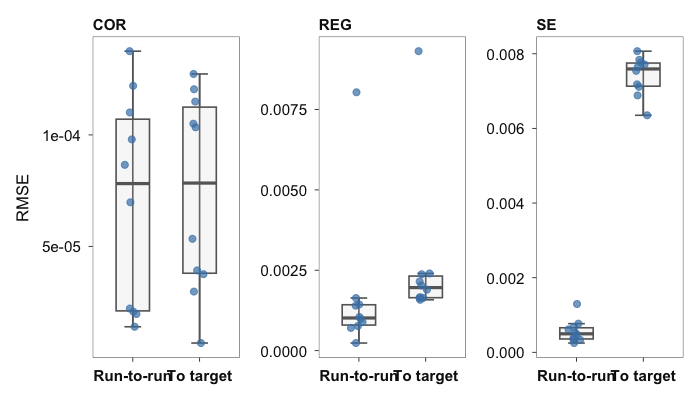

```r
plot_stability(result_par)
```

`plot_fit()` shows the across-run mean difference per statistic, with error bars for the across-run range (`error_type = "range"`, default) or `mean +/- SD` (`error_type = "sd"`); dots mark the individual runs.

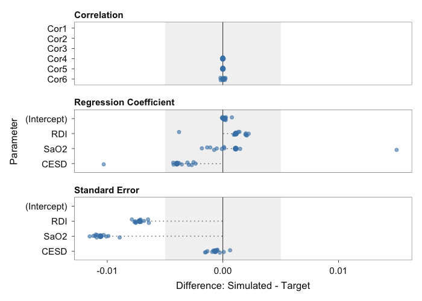

```r
plot_fit(result_par, standardised = FALSE)
```

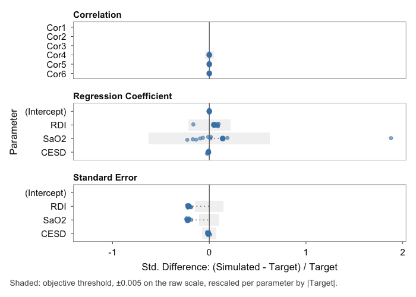

```r
plot_fit(result_par, standardised = TRUE)
```

`plot()` draws `plot_stability()` by default and `plot_fit()` with `which = "fit"`:

```r
plot(result_par)
plot(result_par, which = "fit", standardised = FALSE)
```

## 4.3 Individual runs

The run with the lowest best objective value is stored in `best`; all runs are in `results`. Both are ordinary `stats2data_mlr` objects and support the methods of Section 3:

```r
result_par$best
```

```
#> stats2data MLR result
#>   N:          60
#>   Equation:   Fatigue ~ RDI + SaO2 + CESD
#>   Best objective: 0.00228711
```

```r
get_rmse(result_par$best)
```

```
#> $rmse_cor
#> [1] 3.754068e-05
#>
#> $rmse_reg
#> [1] 0.002400624
#>
#> $rmse_se
#> [1] 0.006351348
```

```r
head(result_par$results[[2]]$data)
```

```
#>         RDI         SaO2 CESD Fatigue
#> 1 110.99972 4.911643e-05   20      19
#> 2  57.21455 3.990472e-03   11      19
#> 3  26.15128 1.667972e+01   15       6
#> 4  15.00154 3.793747e+01   17      15
#> 5  16.38092 3.470481e+01   22      10
#> 6  77.74864 3.457109e+00   17      10
```

## 4.4 Stopping at the first converged run

With `stop_conv = TRUE`, `parallel_optim()` stops launching runs once a run has converged, i.e. its best objective value is below `thresh`. The example repeats the MLR optimization of Section 3 with its full iteration budget:

```r
result_first <- parallel_optim(
  FUN       = optim_mlr,
  args      = args_mlr,
  runs      = 10,
  cores     = 1,
  seed      = 2026,
  stop_conv = TRUE
)
```

```r
result_first
```

```
#> stats2data parallel result
#>   Module: mlr
#>   Runs:   1 of 10 (stopped early)
#>   Converged: TRUE (thresh = 0.005 )
#>   Best objective (across runs): 0.00262738
#>   Mean objective (across runs): 0.00262738
```

1 of 10 requested runs were completed. With `cores > 1`, runs are dispatched in batches of `cores`, so a whole batch completes before the check.

# Shiny interface

All three modules and the parallel workflow are also available in a point-and-click interface:

```r
run_app()
```

The tabs *Descriptives*, *ANOVA*, and *Linear Regression* correspond to `optim_vec()`, `optim_aov()`, and `optim_mlr()`. The inputs of each tab correspond to the arguments of the function (the info icon of each input names the argument), and setting *Number of Runs* above one calls `parallel_optim()`. The results panel offers the plots and summaries shown in this vignette. The *Download* button exports the result object, the simulated data, and the R code of the function call, which reproduces the result in R.

# References

- Bardwell, et al. (2007). https://doi.org/10.1016/j.jad.2006.06.013
- Bardwell, et al. (2003). https://doi.org/10.1176/appi.ajp.160.2.350
- Bengtsson (2021). https://doi.org/10.32614/RJ-2021-048
- Brown & Heathers (2017). https://doi.org/10.1177/1948550616673876
- Heathers, et al. (2018). https://doi.org/10.7287/peerj.preprints.26968v1
- Open Science Collaboration (2015). https://doi.org/10.1126/science.aac4716
- Reynolds & Besner (2008). https://doi.org/10.1037/0278-7393.34.1.50